# MDA Assignment 2

s1935687, Xinyi Qian

# 1 Milk compositions of mammals

Taxonomy of biological organisms is a well established area of biology and typically based on characteristics such as morphology, physiology and behaviour. In this report, we will develop a taxonomy of mammals based on their milk composition.

## 1.1 Summary statistics

Firstly, we can have a look at the summary of the data:

```
##      Water          Protein            Fat           Lactose
##  Min.   :44.90   Min.   : 0.600   Min.   : 1.00   Min.   :0.000
##  1st Qu.:71.30   1st Qu.: 3.000   1st Qu.: 3.40   1st Qu.:2.700
##  Median :82.00   Median : 5.900   Median : 6.30   Median :4.700
##  Mean   :78.18   Mean   : 6.212   Mean   :10.31   Mean   :4.132
##  3rd Qu.:87.70   3rd Qu.: 9.700   3rd Qu.:13.10   3rd Qu.:5.600
##  Max.   :90.40   Max.   :12.300   Max.   :42.00   Max.   :6.900
```

The standard deviations of each constituent of the mammal milk is given by

```
##     Water   Protein       Fat   Lactose
## 12.817913  3.652547 10.517997  1.831830
```

## 1.2 The convenience of standardising the data

From the above summary statistics we see that the standard deviations do differ largely from one constituent of milk to another. It is therefore reasonable to think that standardising data will necessarily have a real impact on the results. Does 1$\%$ change in the milk compositions represent the same thing in lactose as in Water? When comparing the milk compositions of different mammals, failing to standardise the data means attributing the same influence to a difference of 1 degree, whatever the constituent. When standardised, this difference is amplified as it becomes more evident between different constituents of the mammal milk where the percentage of milk compositions vary little from one mammal to another.

## 1.3 Hierarchical clustering analysis

We begin with producing a dendrogram using an adequate distance measure: the Euclidean distance.

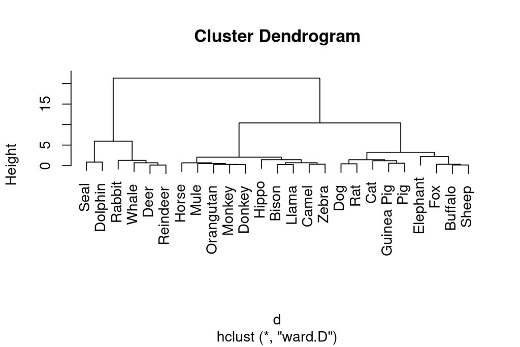

Then, we want to use a hierarchical clustering algorithm and select a sensible number of clusters according to the results. Note that a number of measures or indexes have been proposed for cluster validation, comparison, decision about the number of clusters, etc.

The CH index is based on the ratio of the $\text{between cluster sum of squares}$ to the $\text{within cluster sum of squares}$ (these both are adjusted for the number of clusters considered). You can compute it for a range of possible number of clusters and the largest value determines the optimal number of clusters according to the CH index.

The CH index for a 3-cluster solution and a 4-cluster solution is respectively:

```
## [1] 39.6986
```

```
## [1] 52.84579
```

The ASW is based on the average similarity of an observation to the other observations in the same cluster and the average dissimilarity of that observation to observations in other clusters. The higher the ASW value, the better the classification.

The average silhouette width for a 3-cluster solution and a 4-cluster solution is respectively:

```
## [1] 0.4499791
```

```
## [1] 0.4895634
```

Show the cluster dendrodram again:

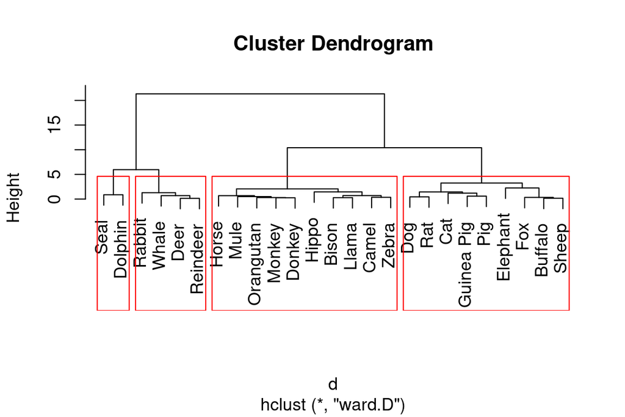

Going ahead with the 4-cluster solution, we now compute some basic statistics to help with the characterisation of the clusters.

```
##          Cluster 1   Cluster 2  Cluster 3 Cluster 4
## Water    0.8048112  0.06799512 -0.8959337 -2.538167
## Protein -0.9971124  0.27049617  1.3450888  1.078152
## Fat     -0.7138241 -0.15076803  0.7859861  2.675604
## Lactose  0.8450567 -0.01140329 -1.0819783 -2.010012
```

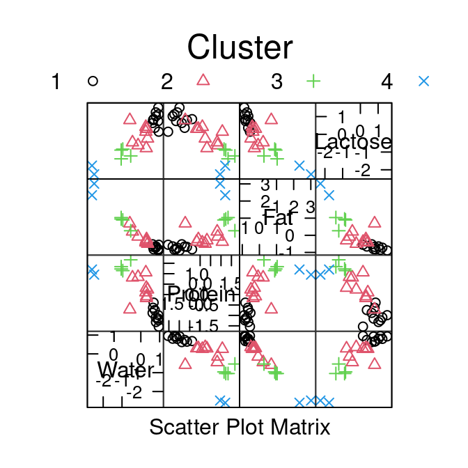

According to the scatterplots, we see that the water constituent is positicely correlated to the lactose constituent (also for the protein vs fat), and the 4 clusters are not overlaped in the plot. So it seems that the differences between mammals are mostly due to differences in the more extreme constituents. Both the water and the lactose are negatively correlated to the fat and the protein.

An informative plot can be built measuring the distances of each constituent to the centre of their respective groups.

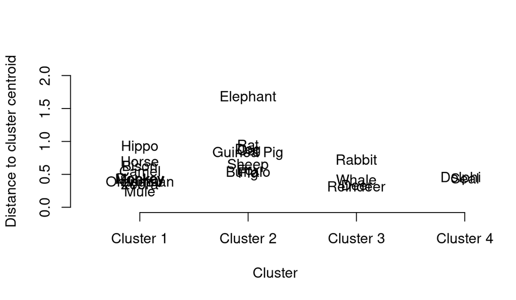

The most homogeneous group is cluster 4. In clusters 1, 2 and 3 we find, respectively, hippos, elephants and rabbits as the most atypical mammals within those groups.

# 2 Code appendix

```r
###############
### Cluster analysis in R
###############


###############
### Mammals milk compositions
###############


###############
### Descriptive Statistics
###############


load("/cloud/project/MammalsMilk.Rdata")
# Visual inspection by constituents

suppressPackageStartupMessages(library(reshape)) # Useful to re-arrange data set
milk.long <- melt(milk,id.vars=c("Name")) # from wide to long format
names(milk.long)[1:3] <- c("Mammal","Constituent","Value")

# Summary statistics
summary(milk[,2:5])
apply(milk[,2:5],2,sd) # Standard deviations

### To standardise or not to standardise?

###############
### Hierarchical clustering analysis
###############


milk2 <- scale(milk[,2:5])
d <- dist(milk2, method = "euclidean") # Distance matrix: Euclidean on standarised variables
hc <- hclust(d, method="ward.D") # Ward's clustering method
plot(hc,labels=milk$Name) # dendrogram

### 4-cluster Solution
plot(hc,labels=milk$Name)
rect.hclust(hc, k=4, border="red") # Show them on the dendrogram

###############
### Cluster Validation
###############


install.packages("fpc")
library(fpc)

### CH Index
clusval3 <- cluster.stats(d,ward3) # Validation stats for a 3-cluster solution
clusval3$ch # CH index for a 3-cluster solution

ward4 <- cutree(hc, k=4) # Extract a 4-cluster solution
clusval4 <- cluster.stats(d,ward4) # Validation stats for a 4-cluster solution
clusval4$ch # CH index for a 4-cluster solution

### Average Silhouette Width (ASW)
clusval3$avg.silwidth # Average silhouette width for a 3-cluster solution
clusval4$avg.silwidth # Average silhouette width for a 4-cluster solution

###############
### Cluster Characteristics
###############


### Cluster centroids (standarised data)
hc4 <- cutree(hc, k=4) # Cluster assignments
st <- by(milk2,hc4,colMeans) # Mean vector by cluster
st <- matrix(unlist(st), nrow = 4)
colnames(st) <- c("Cluster 1","Cluster 2","Cluster 3","Cluster 4")
rownames(st) <- levels(milk.long$Constituent)
st <- as.data.frame(st)
print(st)

### Scatterplot matrix using the groups
milkdat <- cbind(hc4,milk2) # Append grouping information
milkdat <- as.data.frame(milkdat)
library(lattice) # This package simplifies using group colours
a <- splom(~milkdat[c(2:5)], groups = hc4, data = milkdat,
           par.settings = simpleTheme(col = 1:4, pch = 1:4),
           auto.key = list(columns = 4, title = "Cluster"))
print(a)

### Distances to the final cluster centroids (within-group distances)
d1 <- apply(t(milk2[hc4==1,]),2,function(x) dist(rbind(x,st[,1]))) # Cluster 1
d2 <- apply(t(milk2[hc4==2,]),2,function(x) dist(rbind(x,st[,2]))) # Cluster 2
d3 <- apply(t(milk2[hc4==3,]),2,function(x) dist(rbind(x,st[,3]))) # Cluster 3
d4 <- apply(t(milk2[hc4==4,]),2,function(x) dist(rbind(x,st[,4]))) # Cluster 4

c1 <- rep(1:4,times=c(length(d1),length(d2),length(d3), length(d4)))
c2 <- c(as.character(milk$Name[hc4==1]), as.character(milk$Name[hc4==2]),
        as.character(milk$Name[hc4==3]), as.character(milk$Name[hc4==4]))

distances <- data.frame(Cluster=c1,Mammal=c2,Dist=c(d1,d2,d3,d4))

### Plot distances to the cluster centroids
plot(distances$Cluster,distances$Dist,axes=F,ylab="Distance to cluster centroid",
     xlab="Cluster",col="white",xlim=c(0.5,4), ylim=c(0,2))
text(distances$Cluster,distances$Dist,labels=distances$Mammal)
axis(1,at=1:4,labels=c("Cluster 1","Cluster 2","Cluster 3","Cluster 4")); axis(2)
```